# Reducing Estimator Variance in a Random Experiment

Joseph Bolton

[output not shown]

[output cut: 18 more lines]

This post explores various methods for reducing estimator variance in an experiment. Reducing estimator variance allows smaller treatment effects to be detected, or for a treatment effect of the same size to be detected using a smaller sample size.

The situation of interest is as follows:

- We have *training data* data consisting of observations $(y_i, \mathbf{x}_i)$, drawn from some multivariate distribution $p(y,\mathbf{x})$.
- Further points $(y_i, \mathbf{x}_i,T_i)$ are additionally observed, where the response and features $(y_i, \mathbf{x}_i)$ are generated by the same system $p(y,\mathbf{x})$, but each observation $i$ has been subjected either to **treatment** ($T_i=1$) or **no treatment** ($T_i=0$). Those not subjected to the treatment are described as *control* (*holdout*) observations.
- The **treatment** $T_i$ may have some effect on the response $y_i$, and it is measuring the size of this effect that is the central focus of the experiment.

The methods for estimator variance reduction that I’ve assessed are:

[output not shown]

# CUPED (*Controlled-experiment Using Pre-Experiment Data*)

https://www.exp-platform.com/Documents/2013-02-CUPED-ImprovingSensitivityOfControlledExperiments.pdf

$\hat{Y}_{cv}=\overline{Y}-\theta\overline{X} + \theta E\Big[X\Big]$ is an unbiased estimator of $E\Big[Y\Big]$. However, it requires us to know $E\Big[X\Big]$.

The variance of $\hat{Y}_{cv}$ is minimized where $\theta=\displaystyle\frac{COV(Y,X)}{VAR(X)}$. Using this $\theta$, the variance of the estimator is $VAR\Big[\hat{Y}_{cv}\Big]=VAR[\overline{Y}](1-\rho^2)$, where $\rho$ is the correlation between $Y$ and $X$.

Given that $E\Big[X^{(t)}\Big]=E\Big[X^{(c)}\Big]$, then $\Delta_{cv}=\hat{Y}_{cv}^{(t)}-\hat{Y}_{cv}^{(c)}$ is an unbiased estimator of $\delta=E\Big[\Delta\Big]=E\Big[\overline{Y}^{(t)}-\overline{Y}^{(c)}\Big]$. The variance of this estimator is $VAR\Big[\Delta_{cv}\Big]=VAR\Big[\Delta\Big](1-\rho^2)$, where $\rho$ is the correlation between $Y$ and $X$. In order for the estimate to be unbiased, the same $\theta$ must be used for both control and treatment - it can be estimated on both groups pooled together.

```r
run_1_experiment <- function( n_control_group,
                              n_target_group,
                              n_training_group,
                              population_sim_method = c(
                                                         "multivariate_normal",
                                                         "linear_model_with_interactions",
                                                         "feature_partition",
                                                         "random_bsplines_with_interactions"   # not implemented yet
                                                       ),
                              effect_size
                            ){

   results_this_experiment <- c( true_difference = effect_size )

   # simulate populations --------------------------------------------------------------------------------
   if( population_sim_method == "multivariate_normal" ){

       control_mu <- c(
                        y  = 5,
                        x1 = 2,
                        x2 = -1,
                        x3 = 0
                      )

       target_mu <- c(
                       y  = control_mu["y"] + effect_size,
                       x1 = 2,
                       x2 = -1,
                       x3 = 0
                     )
       names(target_mu) <- c("y","x1","x2","x3")

       shared_sigma <- matrix( c(    # y     x1     x2     x3
                                      1  ,   0.2,   0.5,   0.3, # y
                                      0.2,   1  ,   0.7,   0.1, # x1
                                      0.5,   0.7,   1  ,   0.6, # x2
                                      0.3,   0.1,   0.6,   1     # x3
                                 ),
                               byrow = TRUE,
                               nrow = 4,
                               ncol = 4
                              )
       colnames(shared_sigma) <- c("y","x1","x2","x3")
       rownames(shared_sigma) <- colnames(shared_sigma)

       control_group <-
         MASS::mvrnorm(
                        n     = n_control_group,
                        mu    = control_mu,
                        Sigma = shared_sigma
                      ) %>%
         as_tibble()

       target_group <-
         MASS::mvrnorm(
                        n     = n_target_group,
                        mu    = target_mu,
                        Sigma = shared_sigma
                       ) %>%
         as_tibble()

       training_data <-
         MASS::mvrnorm( n     = n_training_group,
                        mu    = control_mu,
                        Sigma = shared_sigma
                       ) %>%
         as_tibble()

       # assign to target/control using matching on ranger model score:
       potential_target_and_control_group <-
                  MASS::mvrnorm(
                        n     = n_target_group + n_control_group,
                        mu    = control_mu,
                        Sigma = shared_sigma
                       ) %>%
                  as_tibble()
       fit_ranger <- ranger::ranger( formula = y ~ x1 + x2 + x3,
                                        data = training_data
                                   )
       potential_target_and_control_group$yhat <-
         predict( object = fit_ranger,
                    data = potential_target_and_control_group
                )$predictions

       target_control_ratio <- round(  n_target_group / n_control_group  )
       assign_groups_ranger_score <-
         potential_target_and_control_group %>%
            arrange( yhat ) %>%
            mutate( rownumber = row_number(),
                    target_control = if_else( rownumber%%target_control_ratio == 0,
                                              "control",
                                              "target"
                                            )
                  ) %>%
            mutate( y = if_else( target_control == "target",
                                 y + effect_size,
                                 y
                                )
                  )

       # assign to test/holdout by nearest-neighbour matching -------------------------------------------------------
       potential_target_and_control_group <-
            MASS::mvrnorm(
                  n     = n_target_group + n_control_group,
                  mu    = control_mu,
                  Sigma = shared_sigma
                 ) %>%
            as_tibble()

       target_control_ratio <- round(  n_target_group / n_control_group  )

       potential_target_and_control_group$yhat_nearest_neighbour <- as.numeric(NA)     # initialize column

       # calculate estimate of y as response value (y) of nearest neighbour in training data:
       for( customer_i in 1:nrow(potential_target_and_control_group) ){
          customer_i_X <- potential_target_and_control_group[ customer_i, c("x1","x2","x3") ] %>% unlist()
          nearest_training_neighbour_index <-
            which.min(
                        # euclidean distance of customer_i to each customer in the training data:
                         sapply(
                                 1:nrow(training_data),
                                 function(i){ sum(
                                                   ( customer_i_X -
                                                     unlist(training_data[i,c("x1","x2","x3")])
                                                   )^2
                                                 )
                                            }
                               )
            )
          potential_target_and_control_group$yhat_nearest_neighbour[customer_i] <- training_data$y[nearest_training_neighbour_index]
       }

       assign_groups_nearest_neighbour <-
         potential_target_and_control_group %>%
            arrange( yhat_nearest_neighbour ) %>%
            mutate( rownumber = row_number(),
                    target_control = if_else( rownumber%%target_control_ratio == 0,
                                              "control",
                                              "target"
                                            )
                  ) %>%
            mutate( y = if_else( target_control == "target",
                                 y + effect_size,
                                 y
                                )
                  )
```

```r
   } else if( population_sim_method == "linear_model_with_interactions" ){

      x1_effect <- sample(0:10, size=1)
      x2_effect <- sample(0:10, size=1)
      x3_effect <- sample(0:10, size=1)
      x1_x2_effect <- sample(0:10, size=1)
      x1_x3_effect <- sample(0:10, size=1)
      x2_x3_effect <- sample(0:10, size=1)
      x1_x2_x3_effect <- sample(0:10, size=1)

      control_group <- tibble( x1 = runif( n=n_control_group, min=-5, max=5 ),
                               x2 = runif( n=n_control_group, min=-5, max=5 ),
                               x3 = runif( n=n_control_group, min=-5, max=5 )
                             )
      control_group$y <-
            x1_effect*control_group$x1 +
            x2_effect*control_group$x2 +
            x3_effect*control_group$x3 +
            x1_x2_effect*control_group$x1*control_group$x2 +
            x1_x3_effect*control_group$x1*control_group$x3 +
            x2_x3_effect*control_group$x2*control_group$x3 +
            x1_x2_x3_effect*control_group$x1*control_group$x2*control_group$x3 +
            rnorm( nrow(control_group), mean=0, sd=1 )
      control_group <- control_group %>% dplyr::select(y, x1, x2, x3)
      target_group <- tibble( x1 = runif( n=n_target_group, min=-5, max=5 ),
                               x2 = runif( n=n_target_group, min=-5, max=5 ),
                               x3 = runif( n=n_target_group, min=-5, max=5 )
                             )
      target_group$y <-
            effect_size +
            x1_effect*target_group$x1 +
            x2_effect*target_group$x2 +
            x3_effect*target_group$x3 +
            x1_x2_effect*target_group$x1*target_group$x2 +
            x1_x3_effect*target_group$x1*target_group$x3 +
            x2_x3_effect*target_group$x2*target_group$x3 +
            x1_x2_x3_effect*target_group$x1*target_group$x2*target_group$x3 +
            rnorm( nrow(target_group), mean=0, sd=1 )
      target_group <- target_group %>% dplyr::select(y, x1, x2, x3)
      training_data <- tibble( x1 = runif( n=n_training_group, min=-5, max=5 ),
                               x2 = runif( n=n_training_group, min=-5, max=5 ),
                               x3 = runif( n=n_training_group, min=-5, max=5 )
                             )
      training_data$y <-
            x1_effect*training_data$x1 +
            x2_effect*training_data$x2 +
            x3_effect*training_data$x3 +
            x1_x2_effect*training_data$x1*training_data$x2 +
            x1_x3_effect*training_data$x1*training_data$x3 +
            x2_x3_effect*training_data$x2*training_data$x3 +
            x1_x2_x3_effect*training_data$x1*training_data$x2*training_data$x3 +
            rnorm( nrow(training_data), mean=0, sd=1 )
      training_data <- training_data %>% dplyr::select(y, x1, x2, x3)

      # choose target/control using matching on ranger model score -----------------------------------------------------------
      potential_target_and_control_group <-
                  tibble( x1 = runif( n=n_control_group+n_target_group, min=-5, max=5 ),
                          x2 = runif( n=n_control_group+n_target_group, min=-5, max=5 ),
                          x3 = runif( n=n_control_group+n_target_group, min=-5, max=5 )
                        )
      potential_target_and_control_group$y <-
            x1_effect*potential_target_and_control_group$x1 +
            x2_effect*potential_target_and_control_group$x2 +
            x3_effect*potential_target_and_control_group$x3 +
            x1_x2_effect*potential_target_and_control_group$x1*potential_target_and_control_group$x2 +
            x1_x3_effect*potential_target_and_control_group$x1*potential_target_and_control_group$x3 +
            x2_x3_effect*potential_target_and_control_group$x2*potential_target_and_control_group$x3 +
            x1_x2_x3_effect*potential_target_and_control_group$x1*potential_target_and_control_group$x2*potential_target_and_control_group$x3 +
            rnorm( nrow(control_group), mean=0, sd=1 )

       fit_ranger <- ranger::ranger( formula = y ~ x1 + x2 + x3,
                                        data = training_data
                                   )
       potential_target_and_control_group$yhat <-
         predict( object = fit_ranger,
                    data = potential_target_and_control_group
                )$predictions

       target_control_ratio <- round(  n_target_group / n_control_group  )
       assign_groups_ranger_score <-
         potential_target_and_control_group %>%
            arrange( yhat ) %>%
            mutate( rownumber = row_number(),
                    target_control = if_else( rownumber%%target_control_ratio == 0,
                                              "control",
                                              "target"
                                            )
                  ) %>%
            mutate( y = if_else( target_control == "target",
                                 y + effect_size,
                                 y
                                )
                  )

      # assign to test/holdout by nearest-neighbour matching -------------------------------------------------------
      potential_target_and_control_group <-
                  tibble( x1 = runif( n=n_control_group+n_target_group, min=-5, max=5 ),
                          x2 = runif( n=n_control_group+n_target_group, min=-5, max=5 ),
                          x3 = runif( n=n_control_group+n_target_group, min=-5, max=5 )
                        )
      potential_target_and_control_group$y <-
            x1_effect*potential_target_and_control_group$x1 +
            x2_effect*potential_target_and_control_group$x2 +
            x3_effect*potential_target_and_control_group$x3 +
            x1_x2_effect*potential_target_and_control_group$x1*potential_target_and_control_group$x2 +
            x1_x3_effect*potential_target_and_control_group$x1*potential_target_and_control_group$x3 +
            x2_x3_effect*potential_target_and_control_group$x2*potential_target_and_control_group$x3 +
            x1_x2_x3_effect*potential_target_and_control_group$x1*potential_target_and_control_group$x2*potential_target_and_control_group$x3 +
            rnorm( nrow(control_group), mean=0, sd=1 )
```

```r
      target_control_ratio <- round(  n_target_group / n_control_group  )

      potential_target_and_control_group$yhat_nearest_neighbour <- as.numeric(NA)     # initialize column

      # calculate estimate of y as response value (y) of nearest neighbour in training data:
      for( customer_i in 1:nrow(potential_target_and_control_group) ){
          customer_i_X <- potential_target_and_control_group[ customer_i, c("x1","x2","x3") ] %>% unlist()
          nearest_training_neighbour_index <-
          which.min(
                        # euclidean distance of customer_i to each customer in the training data:
                         sapply(
                                 1:nrow(training_data),
                                 function(i){ sum(
                                                   ( customer_i_X -
                                                     unlist(training_data[i,c("x1","x2","x3")])
                                                   )^2
                                                 )
                                            }
                               )
          )
          potential_target_and_control_group$yhat_nearest_neighbour[customer_i] <- training_data$y[nearest_training_neighbour_index]
       }

       assign_groups_nearest_neighbour <-
         potential_target_and_control_group %>%
            arrange( yhat_nearest_neighbour ) %>%
            mutate( rownumber = row_number(),
                    target_control = if_else( rownumber%%target_control_ratio == 0,
                                              "control",
                                              "target"
                                            )
                  ) %>%
            mutate( y = if_else( target_control == "target",
                                 y + effect_size,
                                 y
                                )
                  )


   } else if( population_sim_method == "feature_partition" ){

        x1_split_points <- sort( runif(n=2, min=-5, max=5) )
        x2_split_points <- sort( runif(n=2, min=-5, max=5) )
        x3_split_points <- sort( runif(n=2, min=-5, max=5) )

        partition_means <-
            # 1=below both split points, 2=between the two split points, 3=above both split points
            expand_grid(
                         x1_partition = 1:3,
                         x2_partition = 1:3,
                         x3_partition = 1:3
                        ) %>%
            mutate( partition_mean = sample(0:10, size=n(), replace=TRUE) )

        control_group <- tibble(
                                 x1 = runif( n=n_control_group, min=-5, max=5 ),
                                 x2 = runif( n=n_control_group, min=-5, max=5 ),
                                 x3 = runif( n=n_control_group, min=-5, max=5 )
                               ) %>%
                          mutate( x1_partition = case_when( x1 < min(x1_split_points) ~ 1,
                                                            x1 > max(x1_split_points) ~ 3,
                                                            TRUE ~ 2
                                                          ),
                                  x2_partition = case_when( x2 < min(x2_split_points) ~ 1,
                                                            x2 > max(x2_split_points) ~ 3,
                                                            TRUE ~ 2
                                                          ),
                                  x3_partition = case_when( x3 < min(x3_split_points) ~ 1,
                                                            x3 > max(x3_split_points) ~ 3,
                                                            TRUE ~ 2
                                                          )
                                  ) %>%
                          left_join( partition_means,
                                     by = c("x1_partition", "x2_partition", "x3_partition")
                                   ) %>%          # get the mean of each partition
                          mutate( y = rnorm( n(),
                                             mean = partition_mean,
                                             sd = 2
                                           )
                                ) %>%
                          select( y, x1, x2, x3)

        target_group <- tibble( x1 = runif( n=n_target_group, min=-5, max=5 ),
                                x2 = runif( n=n_target_group, min=-5, max=5 ),
                                x3 = runif( n=n_target_group, min=-5, max=5 )
                              ) %>%
                          mutate( x1_partition = case_when( x1 < min(x1_split_points) ~ 1,
                                                            x1 > max(x1_split_points) ~ 3,
                                                            TRUE ~ 2
                                                          ),
                                  x2_partition = case_when( x2 < min(x2_split_points) ~ 1,
                                                            x2 > max(x2_split_points) ~ 3,
                                                            TRUE ~ 2
                                                          ),
                                  x3_partition = case_when( x3 < min(x3_split_points) ~ 1,
                                                            x3 > max(x3_split_points) ~ 3,
                                                            TRUE ~ 2
                                                          )
                                  ) %>%
                          # get the mean of each partition
                          left_join( partition_means,
                                     by = c("x1_partition", "x2_partition", "x3_partition")
                                   ) %>%
                          mutate( partition_mean = partition_mean + effect_size ) %>%
                          mutate( y = rnorm( n(),
                                             mean = partition_mean,
                                             sd = 2
                                           )
                                ) %>%
                          select( y, x1, x2, x3)
```

```r
        training_data <- tibble( x1 = runif( n=n_training_group, min=-5, max=5 ),
                                 x2 = runif( n=n_training_group, min=-5, max=5 ),
                                 x3 = runif( n=n_training_group, min=-5, max=5 )
                               ) %>%
                          mutate( x1_partition = case_when( x1 < min(x1_split_points) ~ 1,
                                                            x1 > max(x1_split_points) ~ 3,
                                                            TRUE ~ 2
                                                          ),
                                  x2_partition = case_when( x2 < min(x2_split_points) ~ 1,
                                                            x2 > max(x2_split_points) ~ 3,
                                                            TRUE ~ 2
                                                          ),
                                  x3_partition = case_when( x3 < min(x3_split_points) ~ 1,
                                                            x3 > max(x3_split_points) ~ 3,
                                                            TRUE ~ 2
                                                          )
                                ) %>%
                          left_join( partition_means,
                                     by = c("x1_partition", "x2_partition", "x3_partition")
                                   ) %>%          # get the mean of each partition
                          mutate( y = rnorm( n(),
                                             mean = partition_mean,
                                             sd = 2
                                           )
                                ) %>%
                          select( y, x1, x2, x3)

      # choose target/control using matching on ranger model score -----------------------------------------
      potential_target_and_control_group <-
                  tibble( x1 = runif( n=n_target_group+n_control_group, min=-5, max=5 ),
                          x2 = runif( n=n_target_group+n_control_group, min=-5, max=5 ),
                          x3 = runif( n=n_target_group+n_control_group, min=-5, max=5 )
                        ) %>%
                    mutate( x1_partition = case_when( x1 < min(x1_split_points) ~ 1,
                                                      x1 > max(x1_split_points) ~ 3,
                                                      TRUE ~ 2
                                                    ),
                            x2_partition = case_when( x2 < min(x2_split_points) ~ 1,
                                                      x2 > max(x2_split_points) ~ 3,
                                                      TRUE ~ 2
                                                    ),
                            x3_partition = case_when( x3 < min(x3_split_points) ~ 1,
                                                      x3 > max(x3_split_points) ~ 3,
                                                      TRUE ~ 2
                                                    )
                            ) %>%
                    # get the mean of each partition
                    left_join( partition_means,
                               by = c("x1_partition", "x2_partition", "x3_partition")
                             )

       fit_ranger <- ranger::ranger( formula = y ~ x1 + x2 + x3,
                                        data = training_data
                                   )
       potential_target_and_control_group$yhat <-
         predict( object = fit_ranger,
                    data = potential_target_and_control_group
                )$predictions

       target_control_ratio <- round(  n_target_group / n_control_group  )
       assign_groups_ranger_score <-
         potential_target_and_control_group %>%
            arrange( yhat ) %>%
            mutate( rownumber = row_number(),
                    target_control = if_else( rownumber%%target_control_ratio == 0,
                                              "control",
                                              "target"
                                            )
                  ) %>%
            mutate( y = rnorm(
                               n(),
                               mean = partition_mean,
                               sd = 2
                             )
                  ) %>%
            mutate( y = if_else( target_control == "target",
                                 y + effect_size,
                                 y
                                )
                  )

       # assign to test/holdout by nearest-neighbour matching -------------------------------------------------------
       potential_target_and_control_group <-
                  tibble( x1 = runif( n=n_target_group+n_control_group, min=-5, max=5 ),
                          x2 = runif( n=n_target_group+n_control_group, min=-5, max=5 ),
                          x3 = runif( n=n_target_group+n_control_group, min=-5, max=5 )
                        ) %>%
                    mutate( x1_partition = case_when( x1 < min(x1_split_points) ~ 1,
                                                      x1 > max(x1_split_points) ~ 3,
                                                      TRUE ~ 2
                                                    ),
                            x2_partition = case_when( x2 < min(x2_split_points) ~ 1,
                                                      x2 > max(x2_split_points) ~ 3,
                                                      TRUE ~ 2
                                                    ),
                            x3_partition = case_when( x3 < min(x3_split_points) ~ 1,
                                                      x3 > max(x3_split_points) ~ 3,
                                                      TRUE ~ 2
                                                    )
                            ) %>%
                    # get the mean of each partition
                    left_join( partition_means,
                               by = c("x1_partition", "x2_partition", "x3_partition")
                             )
```

```r
      target_control_ratio <- round(  n_target_group / n_control_group  )

      potential_target_and_control_group$yhat_nearest_neighbour <- as.numeric(NA)     # initialize column

      # calculate estimate of y as response value (y) of nearest neighbour in training data:
      for( customer_i in 1:nrow(potential_target_and_control_group) ){
          customer_i_X <- potential_target_and_control_group[ customer_i, c("x1","x2","x3") ] %>% unlist()
          nearest_training_neighbour_index <-
          which.min(
                        # euclidean distance of customer_i to each customer in the training data:
                         sapply(
                                 1:nrow(training_data),
                                 function(i){ sum(
                                                   ( customer_i_X -
                                                     unlist(training_data[i,c("x1","x2","x3")])
                                                   )^2
                                                 )
                                            }
                               )
          )
          potential_target_and_control_group$yhat_nearest_neighbour[customer_i] <- training_data$y[nearest_training_neighbour_index]
       }

       assign_groups_nearest_neighbour <-
         potential_target_and_control_group %>%
            arrange( yhat_nearest_neighbour ) %>%
            mutate( rownumber = row_number(),
                    target_control = if_else( rownumber%%target_control_ratio == 0,
                                              "control",
                                              "target"
                                            )
                  ) %>%
            mutate( y = rnorm(
                               n(),
                               mean = partition_mean,
                               sd = 2
                             )
                  ) %>%
            mutate( y = if_else( target_control == "target",
                                 y + effect_size,
                                 y
                                )
                  )
   }



  # calculate estimators of E[Y|target] - E[Y|control] --------------------------------------------------

  # calculate simple difference mean(target y) - mean(control y):
  results_this_experiment["simple_difference"] <- mean(target_group$y) - mean(control_group$y)

  # CUPAC ranger (random forest):
  training_data_for_model <- data.frame( y  = training_data$y,
                                         x1 = training_data$x1,
                                         x2 = training_data$x2,
                                         x3 = training_data$x3
                                       )
  fit_ranger <- ranger::ranger(
                                  formula = y ~ x1 + x2 + x3,
                                     data = training_data_for_model,
                                num.trees = 500
                              )
  yhat_control <- predict(
                            object = fit_ranger,
                              data = control_group
                         )$predictions
  yhat_target <- predict(
                            object = fit_ranger,
                              data = target_group
                        )$predictions
  pooled_y <- c( control_group$y, target_group$y )
  pooled_yhat <- c( yhat_control, yhat_target )
  # estimate theta:
  theta <- cov( pooled_y, pooled_yhat ) /
           var( pooled_yhat )
  results_this_experiment["cupac_ranger"] <-
             mean(target_group$y) -
             mean(control_group$y) -
             ( theta * mean(yhat_target) ) +
             ( theta * mean(yhat_control) )

  # create matched control group:
  # (sample with replacement)
  combined_target_control <-
    bind_rows( target_group %>% dplyr::select(x1, x2, x3) %>% dplyr::mutate(test_control="test")
               ,
               control_group %>% dplyr::select(x1, x2, x3) %>% dplyr::mutate(test_control="control")
            )
  distmat <- dist(      x = combined_target_control[, c("x1","x2","x3")],
                   method = "euclidean"
                 ) %>%
              as.matrix()
  target_indices <- which(combined_target_control$test_control=="test")
  control_indices <- which(combined_target_control$test_control=="control")
  distmat <- distmat[ target_indices, control_indices ] # rows as only target, columns as only control
  closest_control_indices <- apply(      X = distmat,
                                    MARGIN = 1,                       # apply function to each row
                                       FUN = function(row){ which.min(row) }
                                    )
  matched_control_group <- control_group[closest_control_indices, ]
  results_this_experiment["matched_control"] <- mean(target_group$y) - mean(matched_control_group$y)

  # CUPAC linear model
  training_data_for_model <- data.frame(
                                         y  = training_data$y,
                                         x1 = training_data$x1,
                                         x2 = training_data$x2,
                                         x3 = training_data$x3
                                       )
  fit_lm <- lm( y ~ x1 + x2 + x3 + .*., data=training_data_for_model  )      # including all degree-2 interactions too
  yhat_control <- predict(
                            object = fit_lm,
                           newdata = control_group
                         )
  yhat_target <- predict(
                           object = fit_lm,
                          newdata = target_group
                        )
  pooled_y <- c( control_group$y, target_group$y )
  pooled_yhat <- c( yhat_control, yhat_target )
  # estimate theta:
  theta <- cov( pooled_y, pooled_yhat ) /
           var( pooled_yhat )
  results_this_experiment["cupac_lm"] <-
             mean(target_group$y) -
             mean(control_group$y) -
             ( theta * mean(yhat_target) ) +
             ( theta * mean(yhat_control) )
```

```r
  # stratify y based on quantiles of X:
  combined_target_control <-
      bind_rows( target_group %>% dplyr::mutate(test_control="test")
                 ,
                 control_group %>% dplyr::mutate(test_control="control")
              ) %>%
      mutate( x1_median = median(x1),
              x2_median = median(x2),
              x3_median = median(x3)
            ) %>%
      mutate( stratum = paste0( as.numeric(x1>x1_median),
                                as.numeric(x2>x2_median),
                                as.numeric(x3>x3_median)
                              )
            )
  within_strata_calc <-
    combined_target_control %>%
        group_by( stratum ) %>%
        summarise( n_test_in_stratum = sum( if_else(test_control=="test",1,0) ),
                   n_control_in_stratum = sum( if_else(test_control=="control",1,0) ),
                   sum_test_y_in_stratum = sum( if_else(test_control=="test",y,0) ),
                   sum_control_y_in_stratum = sum( if_else(test_control=="control",y,0) ),
                   .groups = "drop"     # drop grouping after summarise
                 ) %>%
        filter( n_test_in_stratum > 0 & n_control_in_stratum > 0 ) %>%     # discard strata without both test & control
        mutate( # estimate treatment effect on y in each stratum:
                y_diff_est_in_stratum = sum_test_y_in_stratum/n_test_in_stratum -
                                        sum_control_y_in_stratum/n_control_in_stratum
              )
  within_strata_calc$stratum_weight <-
    ( within_strata_calc$n_test_in_stratum + within_strata_calc$n_control_in_stratum ) /
    ( sum(within_strata_calc$n_test_in_stratum) + sum(within_strata_calc$n_control_in_stratum) )

  results_this_experiment["y_stratified"] <- sum( within_strata_calc$y_diff_est_in_stratum * within_strata_calc$stratum_weight )

  # propensity score matching & propensity score weighting ----------------------------------------------------------------
  combined_target_control <-
      bind_rows( target_group %>% dplyr::mutate(test_control="test")
                 ,
                 control_group %>% dplyr::mutate(test_control="control")
              )
  propensity_model_logreg <- glm( formula = test_control ~ x1+x2+x3,
                                     data = combined_target_control %>% mutate( test_control = if_else(test_control=="test",1,0) ),
                                   family = binomial(link="logit")
                                )
  target_group_propensity_scores <- predict(  object = propensity_model_logreg,
                                             newdata = target_group,
                                                type = "response"                # i.e. return predicted probability that y=1
                                    )
  holdout_group_propensity_scores <- predict(  object = propensity_model_logreg,
                                              newdata = control_group,
                                                 type = "response"                # i.e. return predicted probability that y=1
                                    )
  target_y_vec <- target_group$y
  matched_control_y_vec <- target_y_vec * NA
  for( target_customer_i in 1:n_target_group ){
      this_target_customer_propensity_score <- target_group_propensity_scores[ target_customer_i ]
      this_target_customer_y <- target_group$y[target_customer_i]
      closest_holdout_propensity_score_loc <- which.min( abs(this_target_customer_propensity_score-holdout_group_propensity_scores) )
      matched_control_y_vec[ target_customer_i ] <- control_group$y[ closest_holdout_propensity_score_loc ]
  }
  results_this_experiment["y_matched_propensity_score"] <- mean(target_y_vec) - mean(matched_control_y_vec)

  # technique from "http://www.math.umd.edu/~slud/s818M-MissingData/PropensityScoreWeightingR.pdf"
  target_propensity_score_weights <- 1 / target_group_propensity_scores
  target_mean_y_propensity_score_weighted <- sum( target_group$y * target_propensity_score_weights ) / sum(target_propensity_score_weights)
  control_propensity_score_weights <- 1 / (1-holdout_group_propensity_scores)
  control_mean_y_propensity_score_weighted <- sum( control_group$y * control_propensity_score_weights ) / sum(control_propensity_score_weights)

  results_this_experiment["propensity_score_weighting"] <- target_mean_y_propensity_score_weighted - control_mean_y_propensity_score_weighted

  # reduce variance with linear regression model:
  combined_target_control <-
    bind_rows( target_group %>% dplyr::mutate(test_control="test")
               ,
               control_group %>% dplyr::mutate(test_control="control")
             ) %>%
    mutate( test_control = factor(test_control, levels=c("control","test")) )
  fit_lm <- lm( formula = y ~ x1 + x2 + x3 + test_control,
                   data = combined_target_control
              )
  results_this_experiment["reduce_variance_by_lm"] <- coef(fit_lm)["test_controltest"]

  # matching using y_hat from lm
  # (future idea: could alternatively only include covariates X passing a chosen correlation threshold with Y)
  predict_y_lm <- lm(
                      formula = y ~ x1 + x2 + x3,
                         data = training_data
                    )
  yhat_control <- predict(
                            object = predict_y_lm,
                           newdata = control_group
                         )
  yhat_target <- predict(
                            object = predict_y_lm,
                           newdata = target_group
                         )
  matched_y_vec <- rep( as.numeric(NA), n_target_group)     # vector to store yhat value of matched control samples
  for( target_customer_i in 1:n_target_group ){
    yhat_target_customer_i <- yhat_target[target_customer_i]
    matched_y_vec[target_customer_i] <-
      # compare this target customer to every control customer, and save the closest one
      control_group$y[ which.min( abs(yhat_target_customer_i - yhat_control) ) ]
  }
  results_this_experiment["match_on_yhat_lm"] <- mean(target_group$y) - mean(matched_y_vec)
```

```r
  # matching using y_hat from ranger (random forest):
  fit_y_ranger <- ranger::ranger(
                      formula = y ~ x1 + x2 + x3,
                         data = training_data
                    )
  yhat_control <- predict(
                            object = fit_y_ranger,
                              data = control_group
                          )$predictions
  yhat_target <- predict(
                            object = fit_y_ranger,
                              data = target_group
                        )$predictions
  matched_y_vec <- rep( as.numeric(NA), n_target_group)     # vector to store yhat value of matched control samples
  for( target_customer_i in 1:n_target_group ){
    yhat_target_customer_i <- yhat_target[target_customer_i]
    matched_y_vec[target_customer_i] <-
      # compare this target customer to every control customer, and save the closest one
      control_group$y[ which.min( abs(yhat_target_customer_i - yhat_control) ) ]
  }
  results_this_experiment["match_on_yhat_ranger"] <- mean(target_group$y) - mean(matched_y_vec)

  # pre-matching on ranger score
  results_this_experiment["group_assign_on_yhat_ranger"] <-
    mean( assign_groups_ranger_score$y[ assign_groups_ranger_score$target_control=="target" ] ) -
    mean( assign_groups_ranger_score$y[ assign_groups_ranger_score$target_control=="control" ] )

  # propensity matching using "MatchIt" --------------------------
  combined_target_control <-
    bind_rows( target_group %>% dplyr::mutate(test_control=1)
               ,
               control_group %>% dplyr::mutate(test_control=0)
             )
  suppressWarnings(
    run_matchit <- matchit( formula = test_control ~ x1 + x2 + x3,
                               data = combined_target_control,
                             method = "nearest",
                            replace = TRUE
                          )
  )
  #plot(run_matchit, type="hist")
  matchit_result_data <- match.data( run_matchit )
  matchit_result_data_test <- matchit_result_data %>% filter(test_control==1)
  matchit_result_data_control <- matchit_result_data %>% filter(test_control==0)
  results_this_experiment["matchit_propensity_score"] <-
    mean( matchit_result_data_test$y ) -   # mean of y in test group
    (
      # weighted mean of y in matched control group
      sum( matchit_result_data_control$y * matchit_result_data_control$weights) /
      sum( matchit_result_data_control$weights )
    )

  # CUPED CCA ----------------------------
  combined_target_control <-
    bind_rows( target_group %>% dplyr::mutate(test_control="test")
               ,
               control_group %>% dplyr::mutate(test_control="control")
             )
  # scale the columns in the training data:
  training_data$scaled_y <- ( training_data$y - mean(training_data$y) ) /
                                      sd( training_data$y )
  training_data$scaled_x1 <- ( training_data$x1 - mean(training_data$x1) ) /
                                      sd( training_data$x1 )
  training_data$scaled_x2 <- ( training_data$x2 - mean(training_data$x2) ) /
                                      sd( training_data$x2 )
  training_data$scaled_x3 <- ( training_data$x3 - mean(training_data$x3) ) /
                                      sd( training_data$x3 )

  run_cca <- CCA::cc(
                      X = training_data %>% select(scaled_x1, scaled_x2, scaled_x3) %>% as.matrix(),
                      Y = training_data %>% select(scaled_y) %>% as.matrix()
                    )
  cca_weights <- c( run_cca$xcoef )
  names(cca_weights) <- c("x1","x2","x3")
  combined_target_control$cca_xvar <- cca_weights[1] * c(scale(combined_target_control$x1)) +
                                      cca_weights[2] * c(scale(combined_target_control$x2)) +
                                      cca_weights[3] * c(scale(combined_target_control$x3))
  target_cca_xvar <- combined_target_control %>% filter(test_control=="test") %>% pull(cca_xvar)
  control_cca_xvar <- combined_target_control %>% filter(test_control=="control") %>% pull(cca_xvar)
  # estimate theta:
  theta <- cov( combined_target_control$y, combined_target_control$cca_xvar ) /
           var( combined_target_control$cca_xvar )
  results_this_experiment["cca_cuped"] <-
             mean(target_group$y) -
             mean(control_group$y) -
             ( theta * mean(target_cca_xvar) ) +
             ( theta * mean(control_cca_xvar) )

  # CUPED CCA naughty ----------------------------
  combined_target_control <-
    bind_rows( target_group %>% dplyr::mutate(test_control="test")
               ,
               control_group %>% dplyr::mutate(test_control="control")
             )
  # scale the columns:
  combined_target_control$scaled_y <- ( combined_target_control$y - mean(combined_target_control$y) ) /
                                      sd( combined_target_control$y )
  combined_target_control$scaled_x1 <- ( combined_target_control$x1 - mean(combined_target_control$x1) ) /
                                      sd( combined_target_control$x1 )
  combined_target_control$scaled_x2 <- ( combined_target_control$x2 - mean(combined_target_control$x2) ) /
                                      sd( combined_target_control$x2 )
  combined_target_control$scaled_x3 <- ( combined_target_control$x3 - mean(combined_target_control$x3) ) /
                                      sd( combined_target_control$x3 )

  run_cca <- CCA::cc(
                      X = combined_target_control %>% select(scaled_x1, scaled_x2, scaled_x3) %>% as.matrix(),
                      Y = combined_target_control %>% select(scaled_y) %>% as.matrix()
                    )
  cca_weights <- c( run_cca$xcoef )
  names(cca_weights) <- c("x1","x2","x3")
  combined_target_control$cca_xvar <- cca_weights[1] * combined_target_control$scaled_x1 +
                                      cca_weights[2] * combined_target_control$scaled_x2 +
                                      cca_weights[3] * combined_target_control$scaled_x3
  target_cca_xvar <- combined_target_control %>% filter(test_control=="test") %>% pull(cca_xvar)
  control_cca_xvar <- combined_target_control %>% filter(test_control=="control") %>% pull(cca_xvar)
  # estimate theta:
  theta <- cov( combined_target_control$y, combined_target_control$cca_xvar ) /
           var( combined_target_control$cca_xvar )
  results_this_experiment["cca_naughty"] <-
             mean(target_group$y) -
             mean(control_group$y) -
             ( theta * mean(target_cca_xvar) ) +
             ( theta * mean(control_cca_xvar) )
```

```r
  # pre-matching on nearest-neighbour y estimate:
  results_this_experiment["group_assign_on_yhat_knn"] <-
    mean( assign_groups_nearest_neighbour$y[ assign_groups_nearest_neighbour$target_control=="target" ] ) -
    mean( assign_groups_nearest_neighbour$y[ assign_groups_nearest_neighbour$target_control=="control" ] )


  # multivariate CUPED using PCA -------------------------------------
  combined_target_control <-
    bind_rows( target_group %>% dplyr::mutate(test_control="test")
               ,
               control_group %>% dplyr::mutate(test_control="control")
             )
  principal_components <-
    stats::prcomp(
                   x = combined_target_control %>% select(x1,x2,x3) %>% as.matrix(),
                   scale = TRUE
                 )$x
  theta1 <- cov( combined_target_control$y, principal_components[,"PC1"] ) /
            var( principal_components[,"PC1"] )
  theta2 <- cov( combined_target_control$y, principal_components[,"PC2"] ) /
            var( principal_components[,"PC2"] )
  theta3 <- cov( combined_target_control$y, principal_components[,"PC3"] ) /
            var( principal_components[,"PC2"] )
  results_this_experiment["multivar_PCA_cuped"] <-
    mean( combined_target_control$y[combined_target_control$test_control=="test"] ) -
    mean( combined_target_control$y[combined_target_control$test_control=="control"] ) -
    theta1 * ( mean( principal_components[combined_target_control$test_control=="test","PC1"] ) -
               mean( principal_components[combined_target_control$test_control=="control","PC1"] )
             ) -
    theta2 * ( mean( principal_components[combined_target_control$test_control=="test","PC2"] ) -
               mean( principal_components[combined_target_control$test_control=="control","PC2"] )
             ) -
    theta3 * ( mean( principal_components[combined_target_control$test_control=="test","PC3"] ) -
               mean( principal_components[combined_target_control$test_control=="control","PC3"] )
             )

  return( results_this_experiment )
}
```

run multiple experiments, and look at the distribution of the results:

```r
# user inputs ------------------------------------------
n_experiments_to_run <- 500
n_control_group <- 50
n_target_group <- 200
n_training_group <- 200
population_simulation_method <- "multivariate_normal"
true_effect_size <- 2
# ------------------------------------------------------

store_experiment_results_matrix <- matrix(
                                           rep( as.numeric(NA), 17 * n_experiments_to_run ),
                                           ncol = 17
                                        )
colnames( store_experiment_results_matrix ) <-
  c(
     "true_difference",
     "simple_difference",
     "cupac_ranger",
     "matched_control",
     "cupac_lm",
     "y_stratified",
     "y_matched_propensity_score",
     "propensity_score_weighting",
     "reduce_variance_by_lm",
     "match_on_yhat_lm",
     "match_on_yhat_ranger",
     "group_assign_on_yhat_ranger",
     "matchit_propensity_score",
     "cca_cuped",
     "cca_naughty",
     "group_assign_on_yhat_knn",
     "multivar_PCA_cuped"
    )
rownames( store_experiment_results_matrix ) <-
  paste( "experiment", 1:n_experiments_to_run )

for( i in 1:n_experiments_to_run ){

  store_experiment_results_matrix[i,] <-
        run_1_experiment(
                                n_control_group = n_control_group,
                                 n_target_group = n_target_group,
                               n_training_group = n_training_group,
                          population_sim_method = population_simulation_method,
                                    effect_size = true_effect_size
                        )
}

head(store_experiment_results_matrix)
```

```
##              true_difference simple_difference cupac_ranger matched_control
## experiment 1               2          2.039949     2.083412        1.928009
## experiment 2               2          1.922159     1.889076        2.125701
## experiment 3               2          2.277073     2.329143        2.002925
## experiment 4               2          1.973724     1.912065        1.961289
## experiment 5               2          2.115153     2.141325        2.174704
## experiment 6               2          2.223481     2.206655        2.310803
##              cupac_lm y_stratified y_matched_propensity_score
## experiment 1 2.095588     2.158920                   2.150280
## experiment 2 2.041551     2.083110                   2.234173
## experiment 3 2.324561     2.181875                   1.944838
## experiment 4 1.882946     1.911015                   1.920935
## experiment 5 2.167446     2.179945                   2.124142
## experiment 6 2.115464     2.191483                   2.130367
##              propensity_score_weighting reduce_variance_by_lm match_on_yhat_lm
## experiment 1                   2.017368              2.024589         2.078974
## experiment 2                   2.132108              2.073399         2.201500
## experiment 3                   2.284003              2.286603         2.169852
## experiment 4                   1.920770              1.899269         1.864125
## experiment 5                   2.130838              2.148627         2.112556
## experiment 6                   2.177144              2.142589         2.094424
##              match_on_yhat_ranger group_assign_on_yhat_ranger
## experiment 1             2.219962                    1.991784
## experiment 2             1.877585                    2.109701
## experiment 3             2.366648                    1.929078
## experiment 4             1.834717                    2.021869
## experiment 5             2.250631                    2.074983
## experiment 6             2.352705                    2.214477
##              matchit_propensity_score cca_cuped cca_naughty
## experiment 1                 2.150280  2.068883    2.005905
## experiment 2                 2.234173  2.020970    2.008789
## experiment 3                 1.944838  2.277765    2.282351
## experiment 4                 1.920935  1.880851    1.888659
## experiment 5                 2.124142  2.179541    2.122265
## experiment 6                 2.130367  2.129235    2.124985
##              group_assign_on_yhat_knn multivar_PCA_cuped
## experiment 1                 1.842225           2.065273
## experiment 2                 1.978551           1.946823
## experiment 3                 2.025963           2.261724
## experiment 4                 1.881306           1.906171
## experiment 5                 2.041324           2.151749
## experiment 6                 1.913169           2.194398
```

```r
mean_estimate_each_method <-
  store_experiment_results_matrix %>%
    as_tibble() %>%
    summarise_all( mean ) %>%
    pivot_longer( cols = everything(),
                  names_to = "estimator",
                  values_to = "mean"
                )

rank_on_multivariate_normal <-
  store_experiment_results_matrix %>%
    as_tibble() %>%
    summarise_all( sd ) %>%
    pivot_longer( cols = everything(),
                  names_to = "estimator",
                  values_to = "standard_deviation"
                ) %>%
    left_join( mean_estimate_each_method,
               by = "estimator"
             ) %>%
    select( estimator, mean, standard_deviation ) %>%
    arrange( standard_deviation ) %>%
    mutate( sd_rank = row_number() ) %>%
    mutate( data_simulation_method = "multivariate_normal" )
```

```r
data_for_plot <-
  tibble(            estimator = "simple_difference",
          estimated_difference = store_experiment_results_matrix[,"simple_difference"]
        )
for( col_j in 3:ncol(store_experiment_results_matrix) ){

  estimator_name <- colnames(store_experiment_results_matrix)[col_j]
  data_for_plot <- bind_rows(
                              data_for_plot
                              ,
                              tibble(            estimator = estimator_name,
                                      estimated_difference = store_experiment_results_matrix[,estimator_name]
                                     )
                   )
}


rank_on_multivariate_normal %>%
  knitr::kable()                     # print as a nice-looking table
```

| estimator | mean | standard_deviation | sd_rank | data_simulation_method |
| --- | --- | --- | --- | --- |
| true_difference | 2.000000 | 0.0000000 | 1 | multivariate_normal |
| group_assign_on_yhat_ranger | 1.994172 | 0.1295963 | 2 | multivariate_normal |
| group_assign_on_yhat_knn | 2.000508 | 0.1322061 | 3 | multivariate_normal |
| cca_cuped | 1.989710 | 0.1347199 | 4 | multivariate_normal |
| reduce_variance_by_lm | 1.996195 | 0.1351475 | 5 | multivariate_normal |
| cca_naughty | 1.972249 | 0.1353998 | 6 | multivariate_normal |
| cupac_lm | 1.989971 | 0.1358953 | 7 | multivariate_normal |
| propensity_score_weighting | 1.997227 | 0.1379246 | 8 | multivariate_normal |
| multivar_PCA_cuped | 1.981575 | 0.1418898 | 9 | multivariate_normal |
| cupac_ranger | 1.991310 | 0.1440949 | 10 | multivariate_normal |
| y_stratified | 1.996193 | 0.1534540 | 11 | multivariate_normal |
| simple_difference | 1.997348 | 0.1628459 | 12 | multivariate_normal |
| match_on_yhat_lm | 1.998421 | 0.1656551 | 13 | multivariate_normal |
| matched_control | 2.003327 | 0.1663817 | 14 | multivariate_normal |
| y_matched_propensity_score | 1.990519 | 0.1783501 | 15 | multivariate_normal |
| matchit_propensity_score | 1.990519 | 0.1783501 | 16 | multivariate_normal |
| match_on_yhat_ranger | 1.996808 | 0.1833517 | 17 | multivariate_normal |

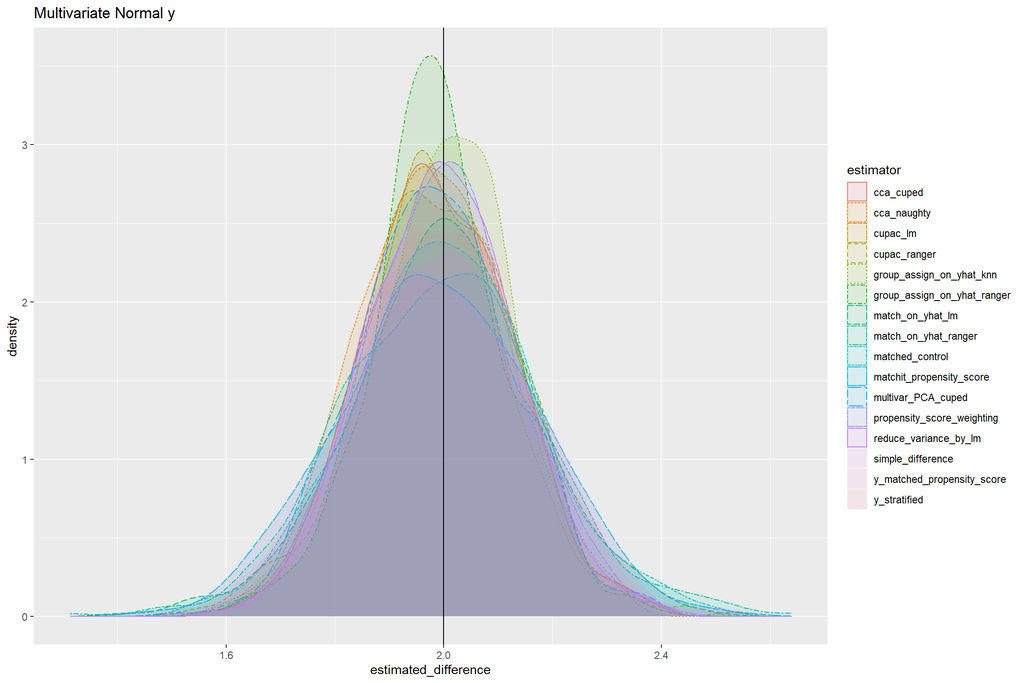

```r
ggplot( data = data_for_plot,
        aes(
                    x = estimated_difference,
             group    = estimator,
             fill     = estimator,
             colour   = estimator,
             linetype = estimator
           )
      ) +
  geom_density( alpha=0.1 ) +
  labs( title = "Multivariate Normal y" ) +
  geom_vline( xintercept = 2 )
```

do the same thing with a different y=1 simulation style:

```r
# user inputs ------------------------------------------
n_experiments_to_run <- 500
n_control_group <- 50
n_target_group <- 200
n_training_group <- 200
population_simulation_method <- "linear_model_with_interactions"
true_effect_size <- 2
# ------------------------------------------------------

store_experiment_results_matrix <- matrix(
                                           rep( as.numeric(NA), 17 * n_experiments_to_run ),
                                           ncol = 17
                                        )
colnames( store_experiment_results_matrix ) <-
  c( "true_difference",
     "simple_difference",
     "cupac_ranger",
     "matched_control",
     "cupac_lm",
     "y_stratified",
     "y_matched_propensity_score",
     "propensity_score_weighting",
     "reduce_variance_by_lm",
     "match_on_yhat_lm",
     "match_on_yhat_ranger",
     "group_assign_on_yhat_ranger",
     "matchit_propensity_score",
     "cca_cuped",
     "cca_naughty",
     "group_assign_on_yhat_knn",
     "multivar_PCA_cuped"
    )
rownames( store_experiment_results_matrix ) <-
  paste( "experiment", 1:n_experiments_to_run )

for( i in 1:n_experiments_to_run ){

  store_experiment_results_matrix[i,] <-
        run_1_experiment(
                                n_control_group = n_control_group,
                                 n_target_group = n_target_group,
                               n_training_group = n_training_group,
                          population_sim_method = population_simulation_method,
                                    effect_size = true_effect_size
                        )
}

head(store_experiment_results_matrix)
```

```
##              true_difference simple_difference cupac_ranger matched_control
## experiment 1               2         24.195448   35.3976918       7.1201768
## experiment 2               2         16.065883   -0.2005352       0.7030567
## experiment 3               2        -26.508550   -9.5047529      -9.5877393
## experiment 4               2          8.138623   -3.1701567      -2.1685219
## experiment 5               2         11.224618   11.5527483      14.1134355
## experiment 6               2         20.815383   17.5829534      14.7297415
##                cupac_lm y_stratified y_matched_propensity_score
## experiment 1 25.6053488   19.0528219                  15.519353
## experiment 2  3.8986281   -0.5190352                  26.518707
## experiment 3  1.9584442  -16.2406533                   2.133997
## experiment 4  0.3376904   -4.1951618                   2.209364
## experiment 5 11.6397844    2.2107607                 -49.366812
## experiment 6 30.7581862   12.8949502                  74.971365
##              propensity_score_weighting reduce_variance_by_lm match_on_yhat_lm
## experiment 1                 3.31360861             34.607812      -15.2172010
## experiment 2                14.88222765             14.793895       12.1148821
## experiment 3               -18.80928467            -18.994237      -14.4055784
## experiment 4                 3.17472120              6.231398        3.6812148
## experiment 5                -0.07323792              7.228502       68.7304597
## experiment 6                51.25963528             35.437159       -0.4607867
##              match_on_yhat_ranger group_assign_on_yhat_ranger
## experiment 1            36.918152                  -35.143525
## experiment 2             6.577779                   15.614477
## experiment 3           -11.641699                   -2.253482
## experiment 4            -1.911438                   11.833208
## experiment 5            -9.191897                    4.084909
## experiment 6             9.972847                   23.069289
##              matchit_propensity_score  cca_cuped cca_naughty
## experiment 1                15.519353  31.877199   33.598904
## experiment 2                26.518707  14.718781   14.749478
## experiment 3                 2.133997 -21.850043  -18.774470
## experiment 4                 2.209364   7.757691    6.142854
## experiment 5               -49.366812  11.061326    7.194813
## experiment 6                74.971365  33.828503   34.580055
##              group_assign_on_yhat_knn multivar_PCA_cuped
## experiment 1              -21.6950329          33.483226
## experiment 2               -5.6162929          14.742912
## experiment 3               -1.8224637         -18.870075
## experiment 4               -0.7727279           6.109917
## experiment 5               -0.8303048           7.196891
## experiment 6                6.1530917          34.610523
```

```r
mean_estimate_each_method <-
  store_experiment_results_matrix %>%
    as_tibble() %>%
    summarise_all( mean ) %>%
    pivot_longer( cols = everything(),
                  names_to = "estimator",
                  values_to = "mean"
                )

rank_on_linear_model_with_interactions <-
  store_experiment_results_matrix %>%
    as_tibble() %>%
    summarise_all( sd ) %>%
    pivot_longer( cols = everything(),
                  names_to = "estimator",
                  values_to = "standard_deviation"
                ) %>%
    left_join( mean_estimate_each_method,
               by = "estimator"
             ) %>%
    select( estimator, mean, standard_deviation ) %>%
    arrange( standard_deviation ) %>%
    mutate( sd_rank = row_number() ) %>%
    mutate( data_simulation_method = "linear_model_with_interactions" )
```

```r
data_for_plot <-
  tibble(            estimator = "simple_difference",
          estimated_difference = store_experiment_results_matrix[,"simple_difference"]
        )
for( col_j in 3:ncol(store_experiment_results_matrix) ){

  estimator_name <- colnames(store_experiment_results_matrix)[col_j]
  data_for_plot <- bind_rows(
                              data_for_plot
                              ,
                              tibble(            estimator = estimator_name,
                                      estimated_difference = store_experiment_results_matrix[,estimator_name]
                                     )
                   )
}


rank_on_linear_model_with_interactions %>%
  knitr::kable()               # print a nice-looking table
```

| estimator | mean | standard_deviation | sd_rank | data_simulation_method |
| --- | --- | --- | --- | --- |
| true_difference | 2.0000000 | 0.000000 | 1 | linear_model_with_interactions |
| group_assign_on_yhat_knn | 0.2830629 | 8.428679 | 2 | linear_model_with_interactions |
| matched_control | 2.2291119 | 12.493884 | 3 | linear_model_with_interactions |
| y_stratified | 2.6567836 | 19.745895 | 4 | linear_model_with_interactions |
| cupac_lm | 1.9010160 | 21.219919 | 5 | linear_model_with_interactions |
| group_assign_on_yhat_ranger | -0.2389099 | 21.684727 | 6 | linear_model_with_interactions |
| cupac_ranger | 1.3565618 | 22.441947 | 7 | linear_model_with_interactions |
| cca_naughty | 2.3038768 | 24.051402 | 8 | linear_model_with_interactions |
| multivar_PCA_cuped | 2.3017731 | 24.067434 | 9 | linear_model_with_interactions |
| cca_cuped | 2.0627151 | 24.293441 | 10 | linear_model_with_interactions |
| reduce_variance_by_lm | 2.3281519 | 24.367881 | 11 | linear_model_with_interactions |
| propensity_score_weighting | 2.3898598 | 25.080933 | 12 | linear_model_with_interactions |
| simple_difference | 2.2644106 | 25.192463 | 13 | linear_model_with_interactions |
| match_on_yhat_lm | 2.4249826 | 26.969741 | 14 | linear_model_with_interactions |
| y_matched_propensity_score | 1.6447352 | 28.770517 | 15 | linear_model_with_interactions |
| matchit_propensity_score | 1.6447352 | 28.770517 | 16 | linear_model_with_interactions |
| match_on_yhat_ranger | 1.4337809 | 29.493577 | 17 | linear_model_with_interactions |

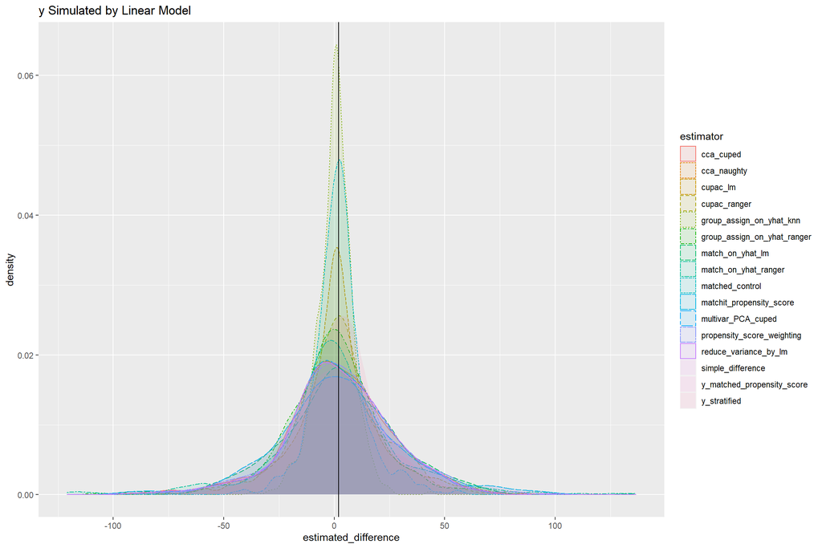

```r
ggplot( data = data_for_plot,
        aes(        x = estimated_difference,
               group  = estimator,
               fill   = estimator,
               colour = estimator,
             linetype = estimator
           )
      ) +
  geom_density( alpha=0.1 ) +
  labs( title = "y Simulated by Linear Model" ) +
  geom_vline( xintercept = 2 )
```

```r
# user inputs ------------------------------------------
n_experiments_to_run <- 500
n_control_group <- 50
n_target_group <- 200
n_training_group <- 200
population_simulation_method <- "feature_partition"
true_effect_size <- 2
# ------------------------------------------------------

store_experiment_results_matrix <- matrix(
                                           rep( as.numeric(NA), 17 * n_experiments_to_run ),
                                           ncol = 17
                                        )
colnames( store_experiment_results_matrix ) <-
  c( "true_difference",
     "simple_difference",
     "cupac_ranger",
     "matched_control",
     "cupac_lm",
     "y_stratified",
     "y_matched_propensity_score",
     "propensity_score_weighting",
     "reduce_variance_by_lm",
     "match_on_yhat_lm",
     "match_on_yhat_ranger",
     "group_assign_on_yhat_ranger",
     "matchit_propensity_score",
     "cca_cuped",
     "cca_naughty",
     "group_assign_on_yhat_knn",
     "multivar_PCA_cuped"
    )
rownames( store_experiment_results_matrix ) <-
  paste( "experiment", 1:n_experiments_to_run )

for( i in 1:n_experiments_to_run ){

  store_experiment_results_matrix[i,] <-
        run_1_experiment(
                                n_control_group = n_control_group,
                                 n_target_group = n_target_group,
                               n_training_group = n_training_group,
                          population_sim_method = population_simulation_method,
                                    effect_size = true_effect_size
                        )
}

head(store_experiment_results_matrix)
```

```
##              true_difference simple_difference cupac_ranger matched_control
## experiment 1               2          2.735372     2.126425        2.652965
## experiment 2               2          2.044635     1.729873        2.171936
## experiment 3               2          2.002538     1.655864        1.856443
## experiment 4               2          2.053570     2.047280        2.091124
## experiment 5               2          2.400378     2.216211        2.383177
## experiment 6               2          2.639761     2.672146        2.542519
##              cupac_lm y_stratified y_matched_propensity_score
## experiment 1 2.858209     3.126969                   1.537059
## experiment 2 1.984610     1.747319                   2.162596
## experiment 3 1.945279     2.023831                   1.297339
## experiment 4 2.261307     2.310865                   2.187745
## experiment 5 1.804057     1.655544                   1.890378
## experiment 6 2.667438     2.614915                   2.864785
##              propensity_score_weighting reduce_variance_by_lm match_on_yhat_lm
## experiment 1                   2.932261              3.095936         3.592030
## experiment 2                   1.767261              1.841484         1.764445
## experiment 3                   1.793964              1.848142         2.150152
## experiment 4                   2.377876              2.390709         2.452973
## experiment 5                   1.939648              1.865423         1.055615
## experiment 6                   2.718834              2.692621         3.352493
##              match_on_yhat_ranger group_assign_on_yhat_ranger
## experiment 1             2.548959                    2.605358
## experiment 2             2.100836                    2.421525
## experiment 3             1.724958                    1.926799
## experiment 4             2.247479                    1.531569
## experiment 5             2.678700                    2.064422
## experiment 6             2.703384                    1.454321
##              matchit_propensity_score cca_cuped cca_naughty
## experiment 1                 1.537059  2.869277    3.036264
## experiment 2                 2.162596  1.814385    1.821576
## experiment 3                 1.297339  1.913326    1.843376
## experiment 4                 2.187745  2.450204    2.372719
## experiment 5                 1.890378  1.854022    1.829223
## experiment 6                 2.864785  2.734978    2.657390
##              group_assign_on_yhat_knn multivar_PCA_cuped
## experiment 1                 1.894129           3.032085
## experiment 2                 1.904513           1.834557
## experiment 3                 2.824744           1.859028
## experiment 4                 1.289494           2.373497
## experiment 5                 1.107387           1.870391
## experiment 6                 1.986227           2.657565
```

```r
mean_estimate_each_method <-
  store_experiment_results_matrix %>%
    as_tibble() %>%
    summarise_all( mean ) %>%
    pivot_longer( cols = everything(),
                  names_to = "estimator",
                  values_to = "mean"
                )

rank_on_feature_partition <-
  store_experiment_results_matrix %>%
    as_tibble() %>%
    summarise_all( sd ) %>%
    pivot_longer( cols = everything(),
                  names_to = "estimator",
                  values_to = "standard_deviation"
                ) %>%
    left_join( mean_estimate_each_method,
               by = "estimator"
             ) %>%
    select( estimator, mean, standard_deviation ) %>%
    arrange( standard_deviation ) %>%
    mutate( sd_rank = row_number() ) %>%
    mutate( data_simulation_method = "feature_partition" )
```

```r
data_for_plot <-
  tibble(            estimator = "simple_difference",
          estimated_difference = store_experiment_results_matrix[,"simple_difference"]
        )
for( col_j in 3:ncol(store_experiment_results_matrix) ){

  estimator_name <- colnames(store_experiment_results_matrix)[col_j]
  data_for_plot <- bind_rows(
                              data_for_plot
                              ,
                              tibble(            estimator = estimator_name,
                                      estimated_difference = store_experiment_results_matrix[,estimator_name]
                                     )
                   )
}

rank_on_feature_partition %>%
  knitr::kable()                    # print a nice-looking table
```

| estimator | mean | standard_deviation | sd_rank | data_simulation_method |
| --- | --- | --- | --- | --- |
| true_difference | 2.000000 | 0.0000000 | 1 | feature_partition |
| group_assign_on_yhat_ranger | 1.973526 | 0.3877149 | 2 | feature_partition |
| group_assign_on_yhat_knn | 1.989301 | 0.4209591 | 3 | feature_partition |
| cupac_ranger | 1.979166 | 0.4295977 | 4 | feature_partition |
| cupac_lm | 1.973204 | 0.5150617 | 5 | feature_partition |
| match_on_yhat_ranger | 1.989631 | 0.5316009 | 6 | feature_partition |
| cca_cuped | 1.969356 | 0.5343377 | 7 | feature_partition |
| cca_naughty | 1.954592 | 0.5364803 | 8 | feature_partition |
| multivar_PCA_cuped | 1.954036 | 0.5365632 | 9 | feature_partition |
| reduce_variance_by_lm | 1.979607 | 0.5419003 | 10 | feature_partition |
| matched_control | 1.974118 | 0.5427512 | 11 | feature_partition |
| y_stratified | 1.968914 | 0.5468953 | 12 | feature_partition |
| propensity_score_weighting | 1.976915 | 0.5502087 | 13 | feature_partition |
| simple_difference | 1.971970 | 0.5793522 | 14 | feature_partition |
| match_on_yhat_lm | 1.964871 | 0.6361221 | 15 | feature_partition |
| y_matched_propensity_score | 1.961586 | 0.6935183 | 16 | feature_partition |
| matchit_propensity_score | 1.961586 | 0.6935183 | 17 | feature_partition |

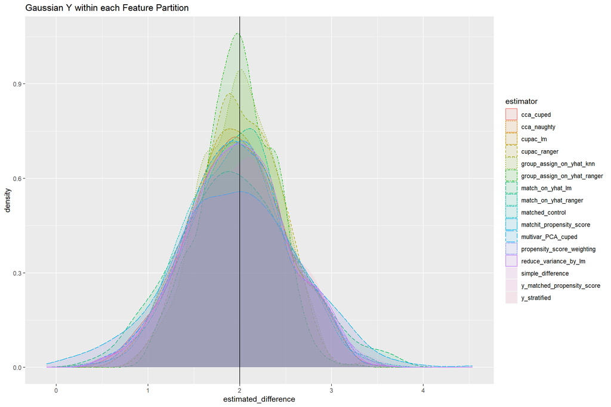

```r
ggplot( data = data_for_plot,      # make the simple difference line thicker
        aes(
                    x = estimated_difference,
             group    = estimator,
             fill     = estimator,
             colour   = estimator,
             linetype = estimator
           )
      ) +
  geom_density( alpha=0.1 ) +
  labs( title = "Gaussian Y within each Feature Partition" ) +
  geom_vline( xintercept = 2 )
```

Rank of each estimator (in terms of minimizing variance) for each simulation method:

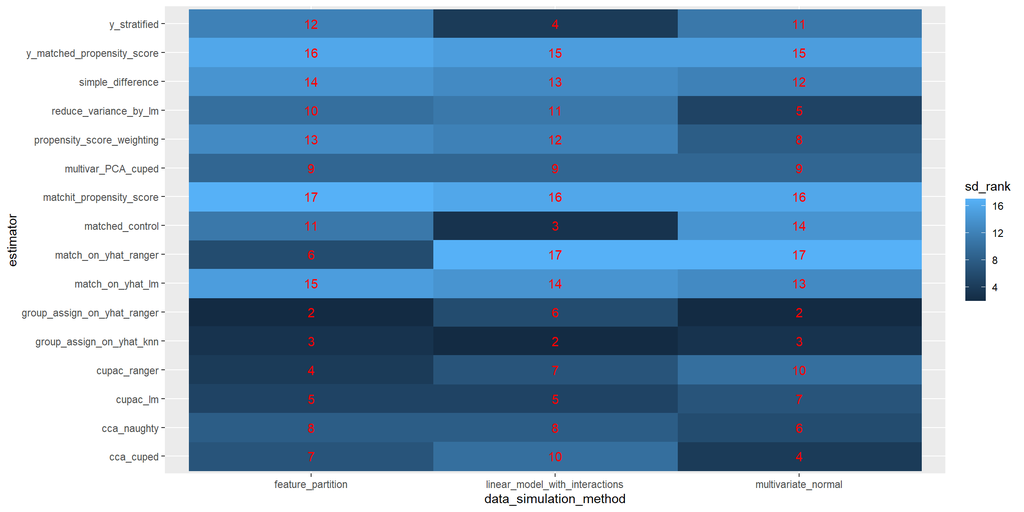

```r
bind_rows( rank_on_multivariate_normal,
           rank_on_linear_model_with_interactions,
           rank_on_feature_partition
         ) %>%
  filter( estimator != "true_difference" ) %>%
  ggplot( data = .,
          aes(      y = estimator,
                    x = data_simulation_method,
                label = sd_rank,
               colour = sd_rank
             )
         ) +
  geom_tile( aes(fill = sd_rank) ) +
  geom_text( colour = "red" )
```

# Some nice resources

- [Modern Algorithms for Matching in Observational Studies](https://www.annualreviews.org/doi/pdf/10.1146/annurev-statistics-031219-041058)
- [Unbiased Variance Reduction in Randomized Experiments](https://arxiv.org/pdf/1904.03817.pdf)
- [Improving the Sensitivity of Online Controlled Experiments by Utilizing Pre-Experiment Data (CUPED)](https://exp-platform.com/cuped/)
- [Improving Experimental Power through Control Using Predictions as Covariate (CUPAC)](https://doordash.engineering/2020/06/08/improving-experimental-power-through-control-using-predictions-as-covariate-cupac/)
- [MatchIt: Nonparametric Preprocessing forParametric Causal Inference](https://r.iq.harvard.edu/docs/matchit/2.4-20/matchit.pdf)
- [Increasing the sensitivity of A/B tests by utilizing the variance estimates of experimental units](https://research.fb.com/blog/2020/10/increasing-the-sensitivity-of-a-b-tests-by-utilizing-the-variance-estimates-of-experimental-units/)
- [Variance reduction in randomised trials by inverse probability weighting using the propensity score](https://onlinelibrary.wiley.com/doi/full/10.1002/sim.5991)
- [A Pratical Guide for Using Propensity Score Weighting in R](http://www.math.umd.edu/~slud/s818M-MissingData/PropensityScoreWeightingR.pdf)